Pros of wordcloud 1. It reveals the essential words in a corpus during text analysis.

2. They delight and provide emotional connection. Both the creation of a word-cloud and the observation of one help to provide an overall sense of the text. The same visceral response doesn’t happen when staring at a page of text.
3. They’re engaging. Visual representation of data tends to have an impact and generates interest amongst the audience.

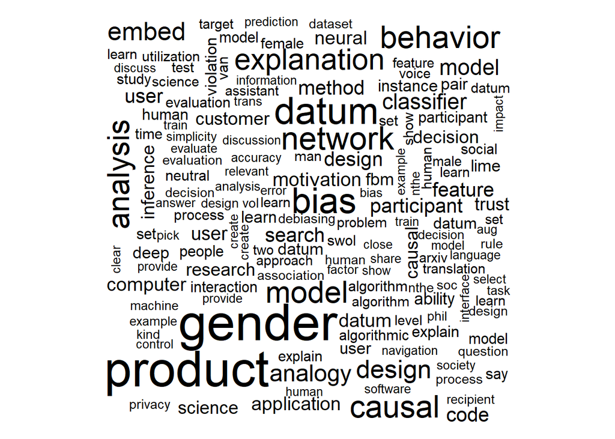

```r
tfidf.text.df = text.df %>% count(document, term) %>%
  bind_tf_idf(term, document, n)

## Filter infrequent words
tfidf.text.df = tfidf.text.df %>% filter(n>8)

## Filter indiscriminate words--very low tf_idf words
tfidf.text.df = tfidf.text.df %>% filter(tf_idf>.000001)

## Create wordcloud of 150 terms
wordcloud(tfidf.text.df$term, tfidf.text.df$n, min.freq = 25)
```

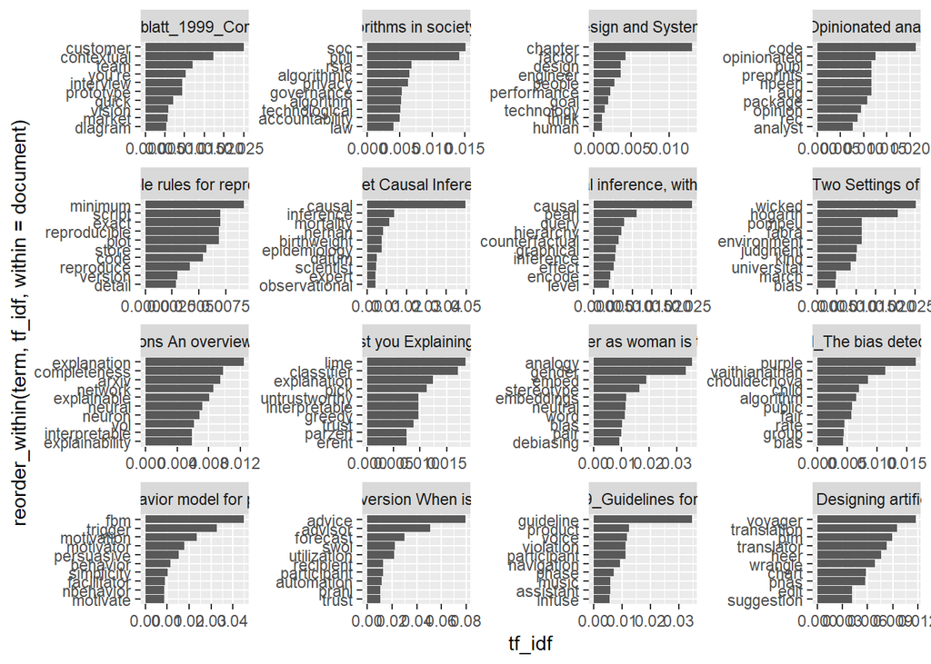

```r
## Plot most discriminating terms
top10.df = tfidf.text.df %>% group_by(document) %>% top_n(10, tf_idf) %>%
  ungroup() %>%
  mutate(document = as.factor(document))

ggplot(top10.df, aes(reorder_within(term, tf_idf, within = document), tf_idf)) +
  geom_col() +
  coord_flip() +
  facet_wrap(.~document, scales = "free")+
  scale_x_reordered()
```

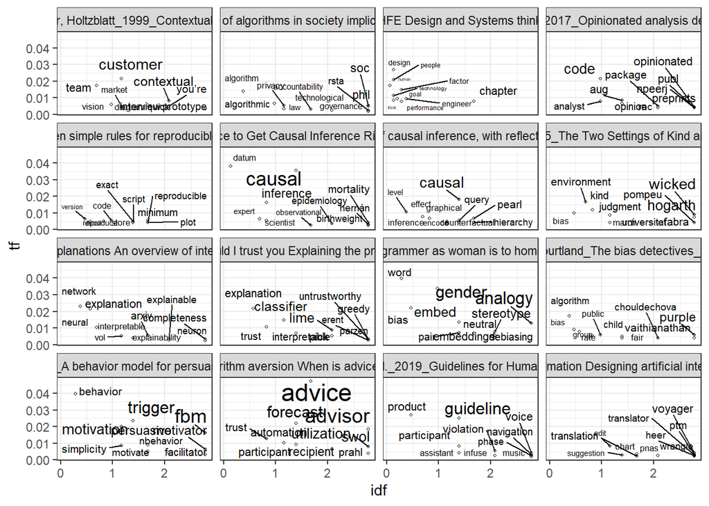

```r
## Scatterplot of term frequency and inverse document frequency for each document
ggplot(top10.df, aes(idf, tf, size = tf_idf)) +
  geom_point(shape = 21, size = .75) +
  geom_text_repel(aes(label = term, size = tf_idf)) +
  facet_wrap(.~document) +
  theme_bw() +
  theme(legend.position = "none")
```

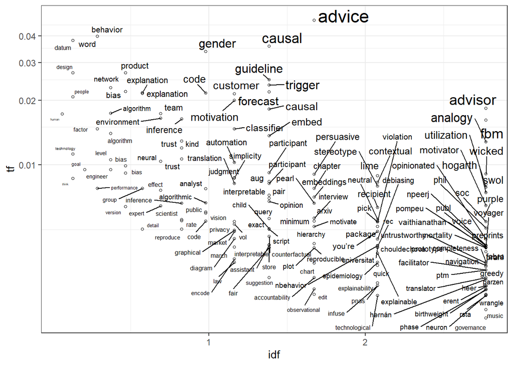

```r
## A single plot of the top tf_idf terms across all documents
ggplot(top10.df, aes(idf, tf, size = tf_idf)) +
  geom_point(shape = 21, size = 1) +
  geom_text_repel(aes(label = term, size = tf_idf)) +
  theme_bw() +
  coord_trans(y="log") +
  theme(legend.position = "none")
```

```r
rm(top10.df)
```

```r
# Convert from tidy format to termXdocument matrix
tdm_weighted.tdmat = cast_tdm(tfidf.text.df, term, document, tf_idf)
tdm_count.tdmat = cast_tdm(tfidf.text.df, term, document, n)

lsa_model <- lsa(tdm_count.tdmat,  dims=dimcalc_share(share = .75))
# dimcalc_share retains that dimensions that retain the required share of the total variance

## Dimensions of the LSA space
# The singular value has a maximum dimensions of the number of documents
dim(lsa_model$tk) # Terms x LSA space
```

```
## [1] 627   9
```

```r
dim(lsa_model$dk) # Documents x LSA space
```

```
## [1] 16  9
```

```r
length(lsa_model$sk) # Singular values
```

```
## [1] 9
```

```r
## Shows expected value of word frequency that for each document
as.textmatrix(lsa_model)
```

```
## $matrix
##                       D1     D2    D3    D4    D5     D6    D7    D8     D9
## 1. contextual       1.28   3.03  0.33  0.46  0.13  -1.68 -0.72  0.14   0.16
## 2. customer         3.33   7.85  0.87  1.18  0.35  -4.36 -1.86  0.35   0.41
## 3. datum           17.72 156.78  2.43 46.50 26.03 128.50 52.64 13.44  21.48
## 4. design          16.37  27.56  4.37  2.32  1.60  -6.15 -2.03  3.31  13.76
## 5. designer         3.42   1.09  1.20  0.17  0.01  -1.14 -0.07  0.55   0.04
## 6. detail           0.83   2.43  0.19  1.90  0.42  -0.34 -0.26  0.13   0.05
## 7. develop          1.06   0.88 -0.05 22.54  3.47  -0.52 -1.51  0.03   0.11
## 8. diagram          0.70   1.65  0.18  0.25  0.07  -0.92 -0.39  0.07   0.09
## 9. environment      0.95   3.16  0.25  0.20  0.26   0.55  0.28  0.29   1.12
## 10. february        0.64   1.52  0.17  0.23  0.07  -0.84 -0.36  0.07   0.08
## 11. focus           0.95   1.91  0.32  0.32  0.01  -1.31  0.04  0.55  18.07
## 12. get             0.58   1.38  0.15  0.21  0.06  -0.77 -0.33  0.06   0.07
## 314. internal       0.06  -0.01  0.05  0.02 -0.04  -0.12  0.25  0.23   8.98
## 315. interpretable  3.06  -0.85 -0.17  0.03 -0.56  -1.06  2.55  0.68  23.86
## 316. key            0.07  -0.01  0.06  0.02 -0.04  -0.13  0.28  0.26   9.98
## 317. layer          0.11  -0.02  0.09  0.03 -0.06  -0.19  0.42  0.39  14.97
## 318. network        3.65  -1.03  0.94  0.12 -0.74  -1.93  4.27  3.78 129.70
## 319. neuron         0.10  -0.02  0.08  0.03 -0.06  -0.18  0.39  0.36  13.97
## 320. operation      0.07  -0.01  0.06  0.02 -0.04  -0.13  0.28  0.26   9.98
## 321. original       1.27  -0.40 -0.13  0.02 -0.28  -0.50  1.15  0.53   8.93
## 322. particular     0.06  -0.01  0.05  0.02 -0.04  -0.12  0.25  0.23   8.98
## 323. pattern        0.09  -0.01  0.07  0.02 -0.05  -0.16  0.33  0.31  11.98
## 324. point          0.06  -0.01  0.05  0.02 -0.04  -0.12  0.25  0.23   8.98
## 325. preprint       0.11  -0.02  0.09  0.03 -0.06  -0.19  0.42  0.39  14.97
## 616. proceeding     0.46   1.95  0.11  0.52  0.26   0.76  0.31  0.15   0.04
## 617. ptm            0.54   2.31  0.13  0.61  0.30   0.90  0.36  0.18   0.05
## 618. quality        0.54   2.31  0.13  0.61  0.30   0.90  0.36  0.18   0.05
## 619. space          0.66   2.84  0.16  0.75  0.37   1.11  0.45  0.22   0.06
## 620. suggestion     0.50   2.13  0.12  0.56  0.28   0.83  0.34  0.16   0.04
## 621. transform      0.37   1.60  0.09  0.42  0.21   0.62  0.25  0.12   0.03
## 622. translation    1.37   5.86  0.34  1.55  0.77   2.28  0.92  0.45   0.11
## 623. translator     0.50   2.13  0.12  0.56  0.28   0.83  0.34  0.16   0.04
## 624. view           0.54   2.31  0.13  0.61  0.30   0.90  0.36  0.18   0.05
## 625. visualization  0.37   1.60  0.09  0.42  0.21   0.62  0.25  0.12   0.03
## 626. voyager        0.70   3.02  0.17  0.80  0.40   1.18  0.48  0.23   0.06
## 627. wrangle        0.41   1.78  0.10  0.47  0.23   0.69  0.28  0.13   0.03
##                      D10   D11   D12   D13   D14   D15   D16
## 1. contextual       1.77 -0.34  0.46  2.32 -0.54  1.93  0.91
```

[output cut: 38 more lines]

```
##  [2] "D2 = 1. Olhede, Wolfe_The growing ubiquity of algorithms in society implications , impacts and innovations_2018"
##  [3] "D3 = 2. HFE Design and Systems thinking"
##  [4] "D4 = 3. Parker_2017_Opinionated analysis development"
##  [5] "D5 = 3. Sandve et al._2013_Ten simple rules for reproducible computational research"
##  [6] "D6 = 4. Hernán, Hsu, Healy_2019_A Second Chance to Get Causal Inference Right A Classification of Data Science Tasks (2)"
##  [7] "D7 = 4. Pearl_2019_The seven tools of causal inference, with reflections on machine learning copy (2)"
##  [8] "D8 = 5. Hogarth, Lejarraga, Soyer_2015_The Two Settings of Kind and Wicked Learning Environments"
##  [9] "D9 = 6. Gilpin et al._2019_Explaining explanations An overview of interpretability of machine learning (1)"
## [10] "D10 = 6. Zhang, Goncalves_Why should I trust you Explaining the predictions of any classifier_2015"
## [11] "D11 = 7. Bolukbasi et al._Man is to computer programmer as woman is to homemaker debiasing word embeddings_2016"
## [12] "D12 = 7. Courtland_The bias detectives_2018"
## [13] "D13 = 8. Fogg_2009_A behavior model for persuasive design (1)"
## [14] "D14 = 8. Prahl, Van Swol_Understanding algorithm aversion When is advice from automation discounted_2017 (1)"
## [15] "D15 = 9. Amershi et al._2019_Guidelines for Human-AI Interaction"
## [16] "D16 = 9. Heer_2019_Agency plus automation Designing artificial intelligence into interactive systems"
```

```r
## Calculates LSA on tf_idf weighted terms
lsa_model = lsa(tdm_weighted.tdmat,  dims=dimcalc_share(share = .75))

rm(tdm_count.tdmat)
```

[figure not shown]

```r
## Cosine similarity is equal to 1 for identical documents
doc.similiarity.mat = cosine(t(lsa_model$dk)) # The d component describes the documents

## Calculates the mean tf_idf of each term and selects top 70
temp = tfidf.text.df %>%
  group_by(term) %>%
  summarise(m.tf_idf = mean(tf_idf)) %>%
  cbind(lsa_model$tk) %>% top_n(70, m.tf_idf)

# Cosine similarity of terms
row.names(temp)= temp$term
term.similiarity.mat = cosine(t(temp %>% select(-term, -m.tf_idf)))

doc.dissimilarity.dist = as.dist(1-doc.similiarity.mat)
term.dissimilarity.dist = as.dist(1-term.similiarity.mat)

## Hierarchical clustering
# Setting method = ward.d2 corresponds to agnes clustering
doc.cluster = hclust(doc.dissimilarity.dist, method = "ward.D2", members = NULL)
plot(doc.cluster)
```

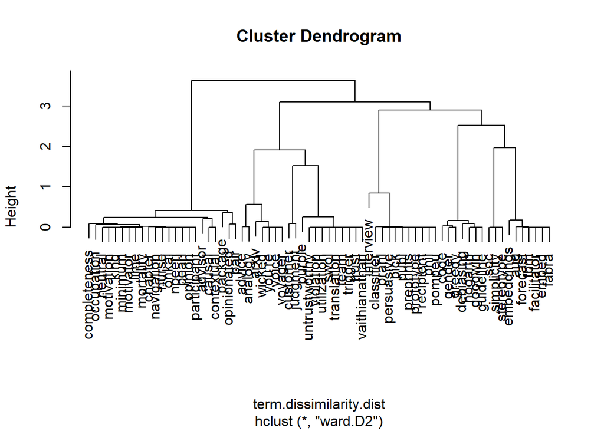

```r
term.cluster = hclust(term.dissimilarity.dist, method = "ward.D2", members = NULL)
plot(term.cluster)
```

```r
rm(temp)
```

#Dimensionality reduction In statistics, machine learning, and information theory, dimensionality reduction or dimension reduction is the process of reducing the number of random variables under consideration by obtaining a set of principal variables. Approaches can be divided into feature selection and feature extraction.

```r
term.umap = umap(lsa_model$tk, n_neighbors = 20, n_components = 2) %>%
  as.tibble()
```

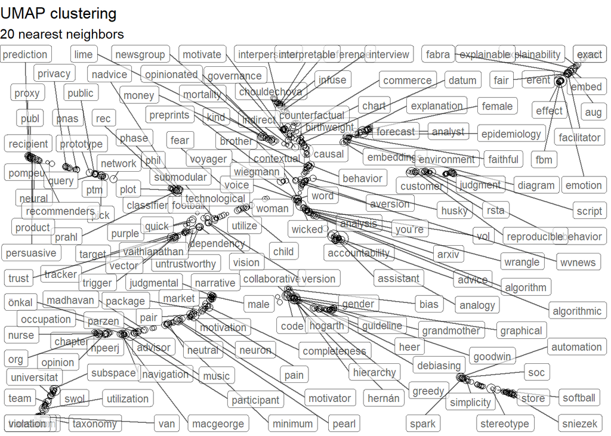

```r
names(term.umap) = c("umap_1", "umap_2")

## Add tf_idf information
term.umap = tfidf.text.df %>% group_by(term) %>%
  summarise(m.tf_idf = max(tf_idf)) %>%
  cbind(term.umap)

## Plot UMAP of terms
term.umap.plot =
  ggplot(term.umap, aes(umap_1, umap_2)) +
  geom_point(aes(size=m.tf_idf),shape = 21) +
  geom_label_repel(data = term.umap %>% top_n(175, m.tf_idf),
                   aes(label = term), alpha = .6, size = 3) +
  labs(title = "UMAP clustering", subtitle = "20 nearest neighbors") +
  theme_void()+
  theme(legend.position = "none")
term.umap.plot
```

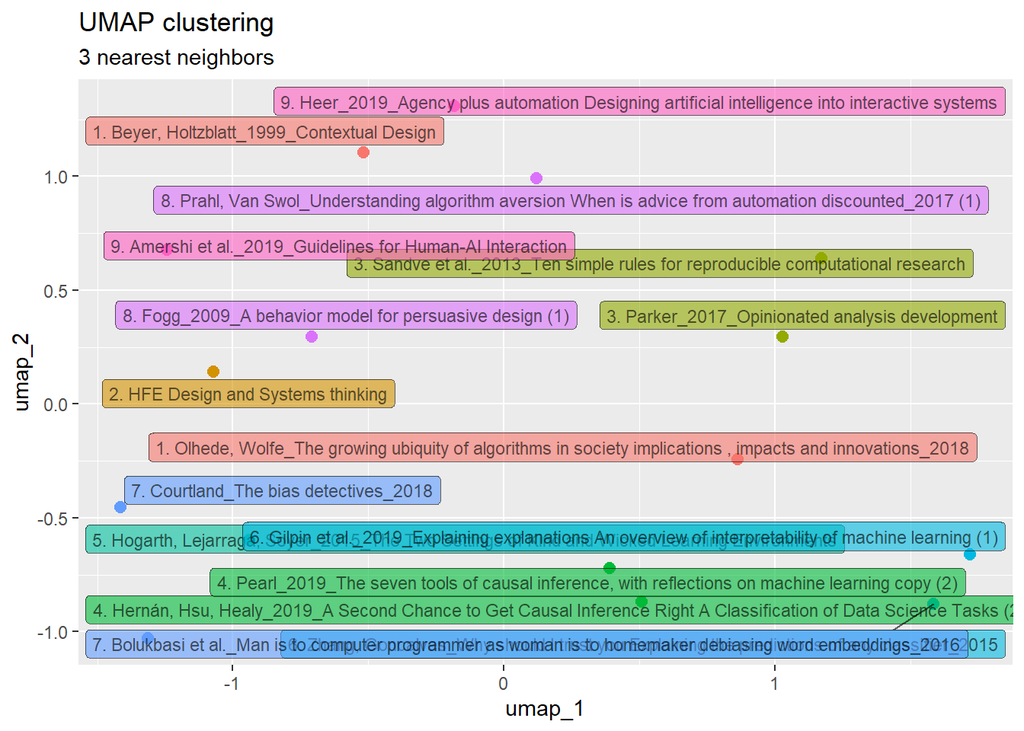

```r
## Plot UMAP of documents
doc.umap =
  umap(lsa_model$dk, n_neighbors = 3, n_components = 2) %>%
  as.tibble()
names(doc.umap) = c("umap_1", "umap_2")
doc.umap = cbind(docs.df, doc.umap)

doc.umap.plot =
  ggplot(doc.umap, aes(umap_1, umap_2)) +
  geom_point(aes(colour = number), size = 2.5) +
  geom_label_repel(aes(label = document, fill = number), alpha = .6, size = 3) +
  labs(title = "UMAP clustering", subtitle = "3 nearest neighbors") +
  theme(legend.position = "none")
doc.umap.plot
```

```r
ggsave(doc.umap.plot, filename = "doc.umap.pdf", width = 8, height = 8)

rm(term.umap, term.cluster, doc.umap.plot, doc.umap)
```

```r
## Convert tidytext to spars metrix for stm analysis
text.sparse = tfidf.text.df %>% cast_sparse(document, term, n)

## Fit structural topic model for a range of topics
multi_stm.fit = searchK(text.sparse,
                      K= c(3, 4, 5, 6, 7, 8, 9, 10, 11, 12, 13),
                      M = 12, # number of top words for exclusivity calculation
                      init.type = "Spectral",
                      N = 4, # Number of documents partially held out, 10% by default
                      proportion = 0.5, # Held out documents for likelihood calculation
                      heldout.seed = 888, cores = 1)
```

[output not shown]

[output cut: 610 more lines]

[output not shown]

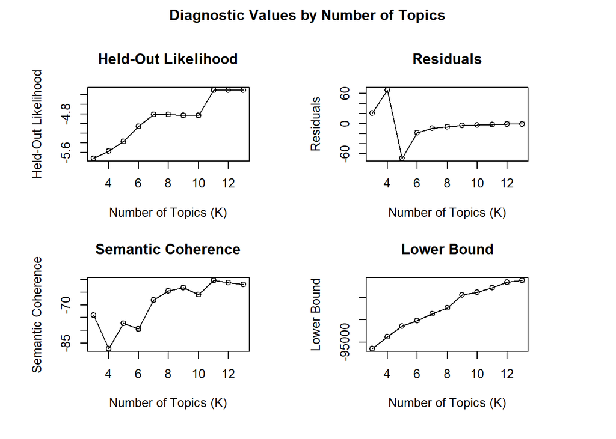

```r
## Plot topic metrics
# Higher heldout likelihood the better
# Lower residual dispersion the better
# Higher semantic coherence and exclusivity
# Higher lower bound of the marginal likelihood (evidence)
plot(multi_stm.fit)
```